# Session 5

How to interpret the latent class

Matt Denwood

2022-06-09

## Recap

- Adding more populations and more tests to a Hui-Walter model is technically easy
  - Particularly if using template_huiwalter
- Verifying that the assumptions you are making are correct is harder
  - The sensitivity and specificity must be consistent
  - Pairwise correlation between tests should be accounted for

# How to interpret the latent class

## What exactly is our latent class?

Think about what exactly the latent class is in these situations:

1. An antigen plus antibody test
- The latent status is probably close to the true disease status
2. Two antibody tests
- The latent status is actually ‘producing antibodies’
  - And not ‘diseased’ !!!
- What do we mean by “conditionally independent”?
  - Independent of each other conditional on the latent state
  - But the latent state is NOT always *disease*

## A hierarchy of latent states

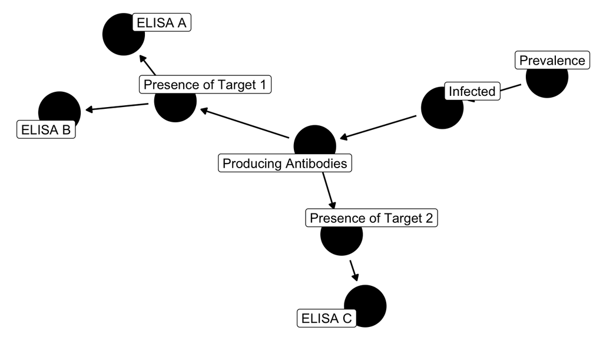

## Branching of processes leading to test results

- Sometimes we have multiple tests detecting similar things
  - For example: two antibody tests and one antigen test
    - The antibody tests will be correlated
- Sometimes we have multiple tests on the same site / sample:
  - For example: two throat swab tests vs a nasal swab test
    - The throat swab tests will be correlated
- Or even three antibody tests where two are primed to detect the same thing, and one has a different target!
  - In this case all three tests are correlated
  - But two are more strongly correlated

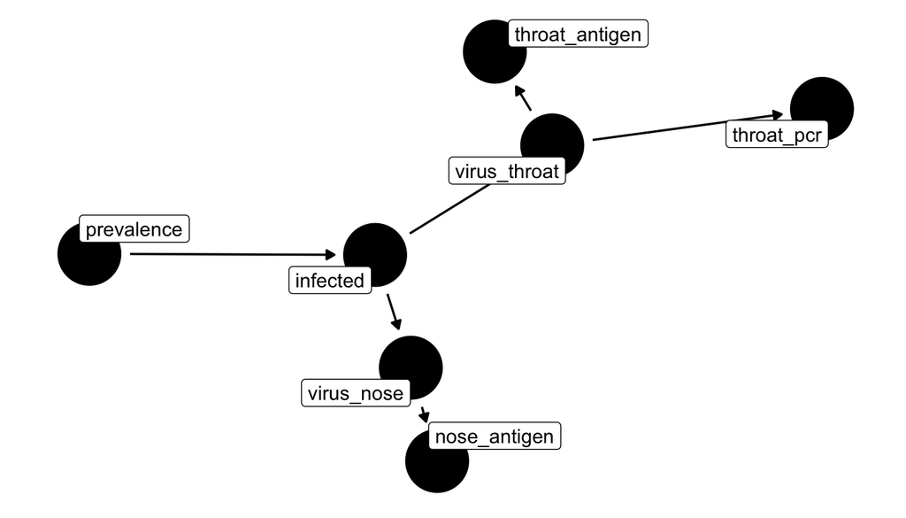

Parasites generally have more complex life cycles

[figure not shown]

Life cycle of liver fluke

So diagnostic tests are more difficult to interpret!

[figure not shown]

Diagnostic tests for liver fluke

What are the tests detecting?

- Faecal egg counts
  - Detect eggs from adult parasites
  - These are produced 8-12 weeks after infection
  - Eggs may persist in the gall bladder for some weeks after infection has been cleared
- Antigen ELISA
  - Detects presence of maturing/adult parasites in faeces
  - This occurs from 5-8 weeks after infection
  - Parasites only detectable during active infection
- Antibody ELISA
  - Triggered by migrating juveniles and adults
  - Persists (although declining) for several months after infection has been cleared

## What is sensitivity and specificity?

- The probability of test status conditional on true disease status?
- The probability of test status conditional on the latent state?

So is the latent state the same as the true disease state?

Important quote:

“Latent class models involve pulling **something** out of a hat, and deciding to call it a rabbit”

- Nils Toft

## Model complexity

How many parameters are in my latent class model?

- 2 x k + d x (d - 1) + p
- Where k=total tests, d=covarying tests, p=populations

BUT remember the effect of priors:

- Se ~ dbeta(1, 1) vs. Se ~ dbeta(2, 1) vs. Se ~ dbeta(2978, 234)

Effective number of parameters:

- pD (and therefore DIC) is ill-defined for LCM
- p_waic (and WAIC) is a better bet - will be much easier in JAGS 5.0!

# Discussion session 5 - when should we correct for correlation?

Aims:

- To get you to think about when and why we should try to correct for correlation
- To get you to think about what is NOT achieved by including correlation terms

Main discussion points for each example:

- What is the latent class
- Which correlation terms should we include and why

Please feel free to hijack the discussion at any point :)

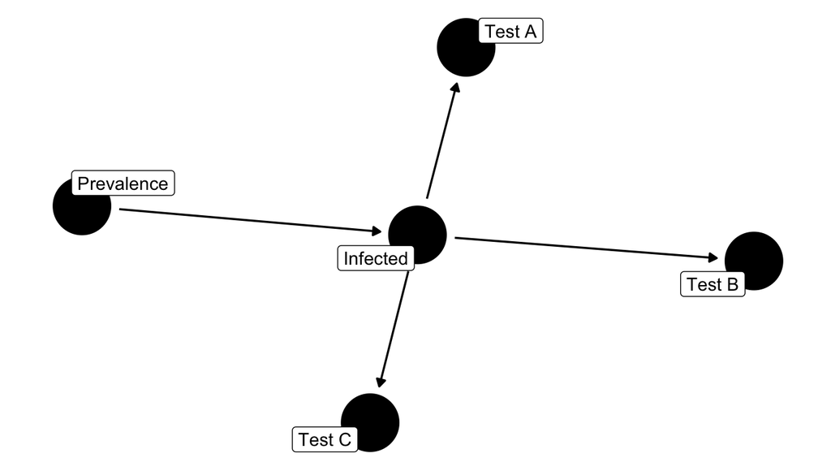

- No correlation to model!

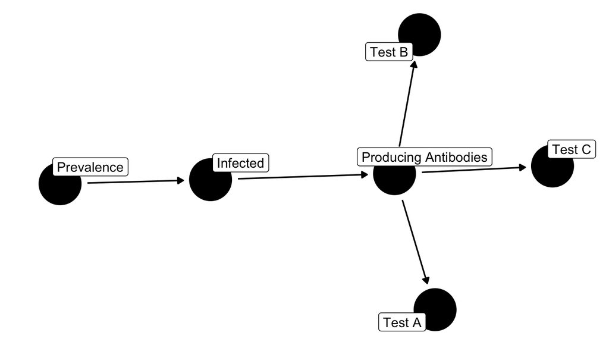

- No correlation to model … but “infected” is not the latent class

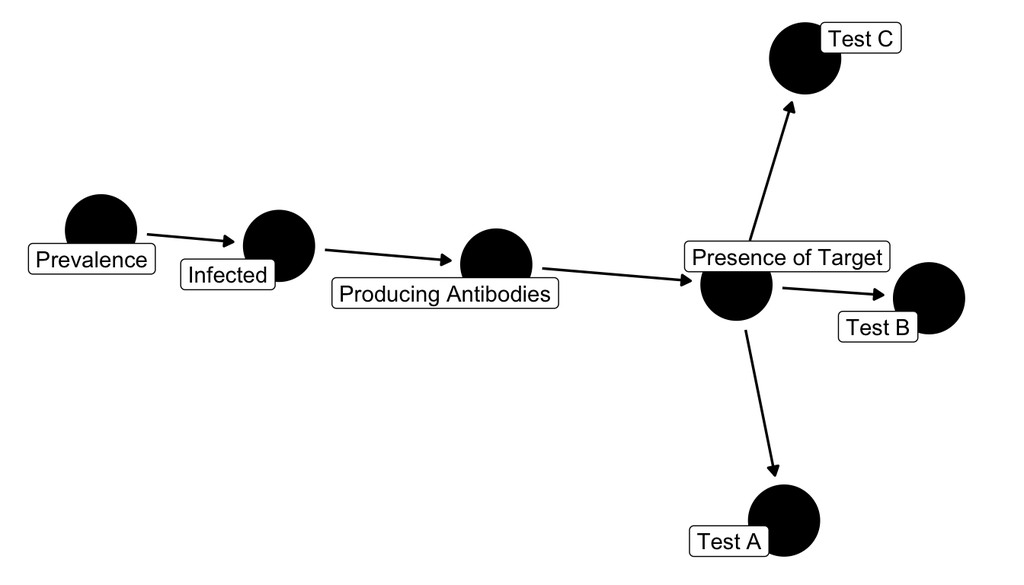

- Same as above!

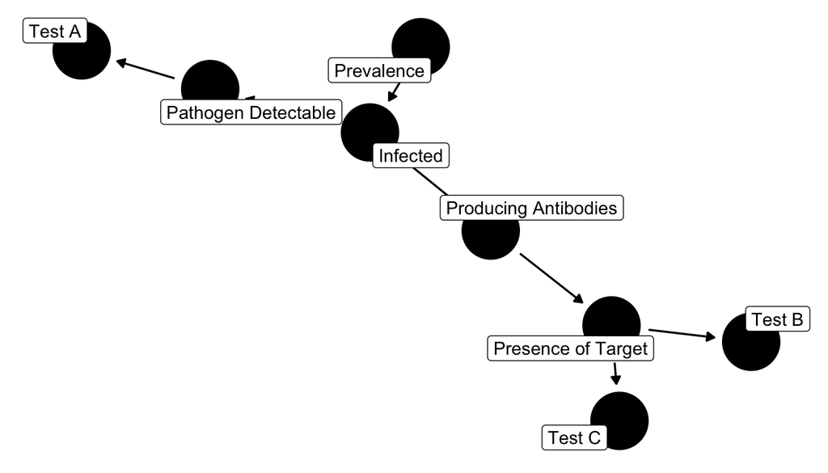

- Tests B and C are correlated

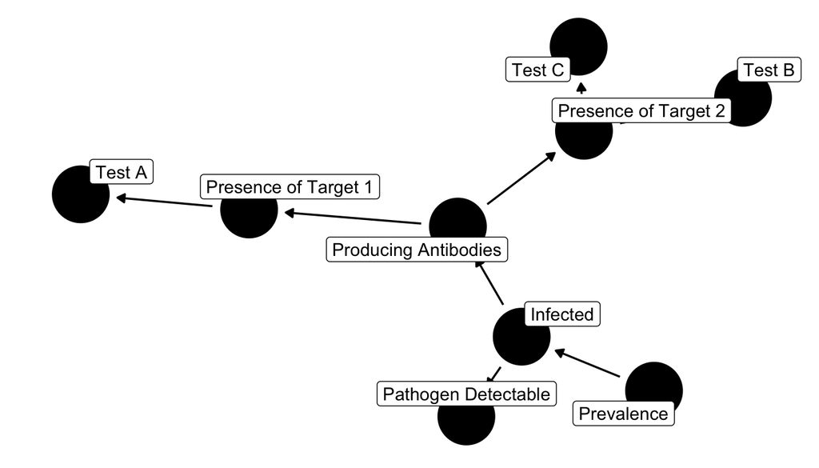

- All tests are correlated with respect to infected BUT infected is not the latent class
- Tests B and C are correlated with respect to antibodies - but maybe not substantially?

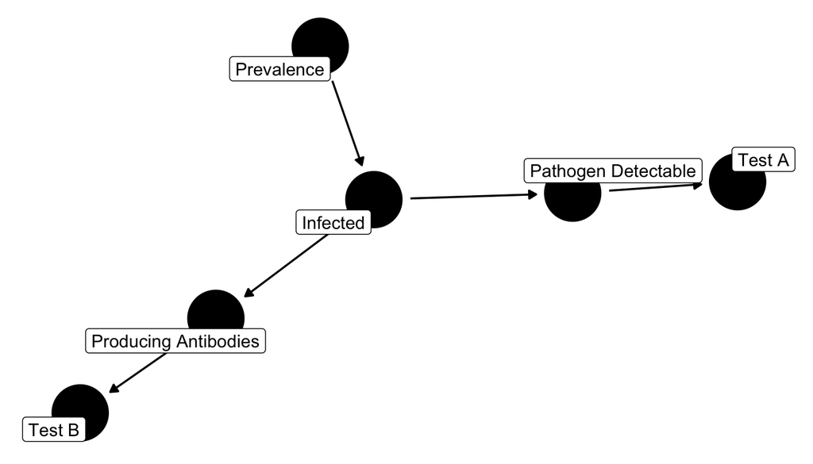

- No correlation to model

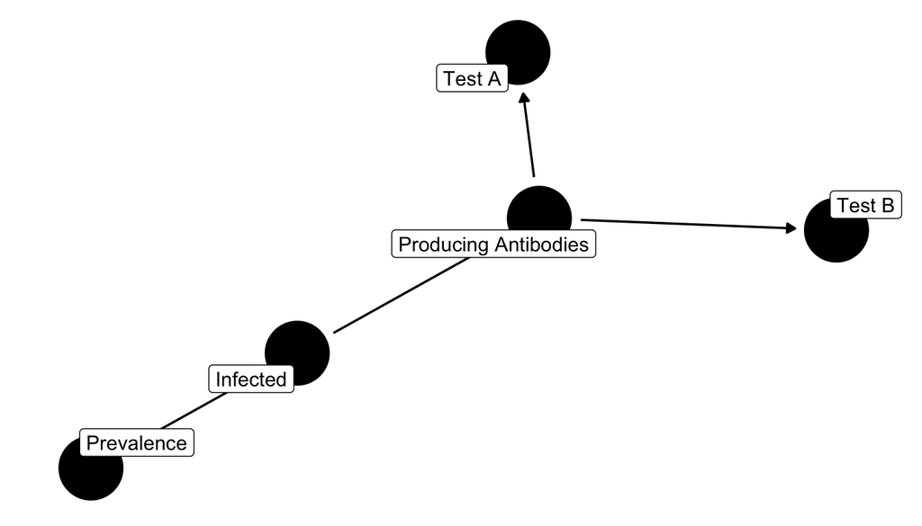

- No correlation to model - but “infected” is not the latent class

## Other examples?

[Insert discussion here…]

## Summary: between-test correlation structure

My approach:

- If you have <3 tests then forget correlation BUT you must (always) consider what the latent class really means
- Otherwise, start with the biology. Which pairwise correlation terms are plausible?
- If you have a LOT of terms then consider eliminating some based on the posterior being close to zero … but check that other estimates do not change substantially between “full” and “reduced” models
- I dislike DIC … maybe WAIC is better?

## Publication of your results

STARD-BLCM: A helpful structure to ensure that papers contain all necessary information

- You should follow this and refer to it in your articles!

If you use the software, please cite JAGS:

- Plummer, M. (2003). JAGS : A Program for Analysis of Bayesian Graphical Models Using Gibbs Sampling JAGS : Just Another Gibbs Sampler. Proceedings of the 3rd International Workshop on Distributed Statistical Computing (DSC 2003), March 20–22,Vienna, Austria. ISSN 1609-395X. https://doi.org/10.1.1.13.3406

And R:

```r
citation()
```

```
##
##
##   R Core Team (2022). R: A language and environment for statistical
##   computing. R Foundation for Statistical Computing, Vienna, Austria.
##   URL https://www.R-project.org/.
##
## A BibTeX entry for LaTeX users is
##
##   @Manual{,
##     title = {R: A Language and Environment for Statistical Computing},
##     author = {{R Core Team}},
##     organization = {R Foundation for Statistical Computing},
##     address = {Vienna, Austria},
##     year = {2022},
##     url = {https://www.R-project.org/},
##   }
##
## We have invested a lot of time and effort in creating R, please cite it
## when using it for data analysis. See also 'citation("pkgname")' for
## citing R packages.
```

And runjags:

```r
citation("runjags")
```

```
##
##
##   Matthew J. Denwood (2016). runjags: An R Package Providing Interface
##   Utilities, Model Templates, Parallel Computing Methods and Additional
##   Distributions for MCMC Models in JAGS. Journal of Statistical
##   Software, 71(9), 1-25. doi:10.18637/jss.v071.i09
##
## A BibTeX entry for LaTeX users is
##
##   @Article{,
##     title = {{runjags}: An {R} Package Providing Interface Utilities, Model Templates, Parallel Computing Methods and Additional Distributions for {MCMC} Models in {JAGS}},
##     author = {Matthew J. Denwood},
##     journal = {Journal of Statistical Software},
##     year = {2016},
##     volume = {71},
##     number = {9},
##     pages = {1--25},
##     doi = {10.18637/jss.v071.i09},
##   }
```